# BANA 4080: Introduction to Data Mining with Python

Week 1: Getting Started

# Welcome to BANA 4080

## Brad Boehmke

- Phonetically: **“Bem”** + **“Key”**
- Alternatives:
  - Dr. / Professor B
  - Brad
- Contact:
  - Read **Communication Expectations** Canvas page first!
  - Email: boehmkbc@ucmail.uc.edu
  - Office: Lindhall 3412

[figure not shown]

[figure not shown]

[figure not shown]

[figure not shown]

## Fun Fact: Golf Obsessed

[video not shown]

## Meet Your TA

### 👋 Eirlys Vo

- Senior in Business Analytics
- Has already taken this course
- Passionate about helping you succeed
- Great resource for coding questions, labs, and homework

📧 Email: vopq@mail.uc.edu  
🕐 Office Hours: TBD

**Important**

Don’t hesitate to reach out — they’re here to support you!

## Today’s Agenda

- What is data mining and why does it matter?
- Course overview, goals, & roadmap
- AI & Tooling
- Q&A

# What is Data Mining

## Data Mining is All Around Us

> Organizations use data mining to drive decisions every day.

**Real-World Examples:**

- 🛒 *Kroger analyzes loyalty card data* to personalize digital coupons.
- 🎶 *Spotify recommends music* based on your listening history and those like you.
- 🏥 *Hospitals use patient data* to predict readmission risks.
- 🏈 *NFL teams analyze player movement data* to improve performance and strategy.
- 📦 *Amazon tracks browsing behavior* to recommend products and optimize inventory.

**Important**

Every time you browse, click, buy, swipe, or stream — you’re generating data.

## What Is Data Mining?

> **The process of uncovering meaningful patterns, trends, and relationships in large data sets**

Why is it important?

- 📈 Helps organizations **make better decisions**
- 🔍 Reveals insights that would otherwise go unnoticed
- 🤖 Powers personalization, prediction, and automation
- 💰 Drives business value in nearly every industry

**Important**

Data mining turns raw information into **actionable knowledge**

## Activity

**Where Do You See Data Mining?**

🤔 Think about your daily routine — when are you being “mined”?

#### Instructions:

1. **Form groups of 2–3 students**
2. Brainstorm at least **3 examples** where you think data mining is happening in your life
3. We’ll share a few examples as a class

💬 Look for clues in:

- Shopping & entertainment
- Health & fitness
- Social media & tech
- Education or travel

Please think about this for 5 minutes.

## So What Does Data Mining Actually Look Like?

> **The process of turning raw, messy data into insight someone can act on**

```
flowchart LR
  A[Raw Data] --> B[Clean & Prepare]
  B --> C[Explore & Visualize]
  C --> D[Model & Predict]
  D --> E[Insight & Action]
```

Every example you just brainstormed runs through this same pipeline — and this course walks you through it end-to-end.

**Important**

The first half of this course covers **getting data ready**. The second half covers **learning from it**.

# The Challenge Ahead

## Meet Taylor

**Taylor** is a college junior who just landed a summer internship at a marketing analytics firm.

**Taylor has a solid foundation:**

- Business knowledge ✓
- Statistical thinking ✓
- Critical thinking ✓

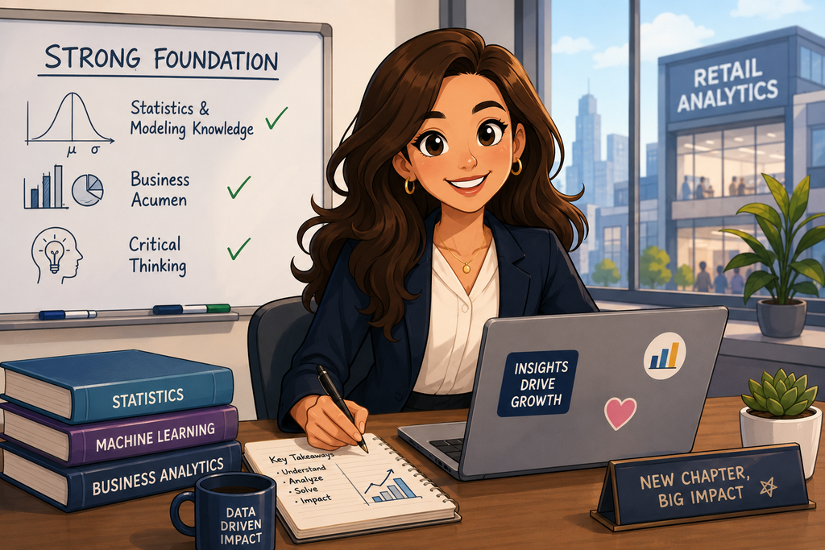

Taylor knows how to think about data!

## Taylor’s First Week on the Job

The manager drops three raw data files and says:

> *“We’re trying to understand what drives repeat purchases. Can you dig into this and pull together something useful by Friday?”*

**Taylor opens the files and freezes.** 😰

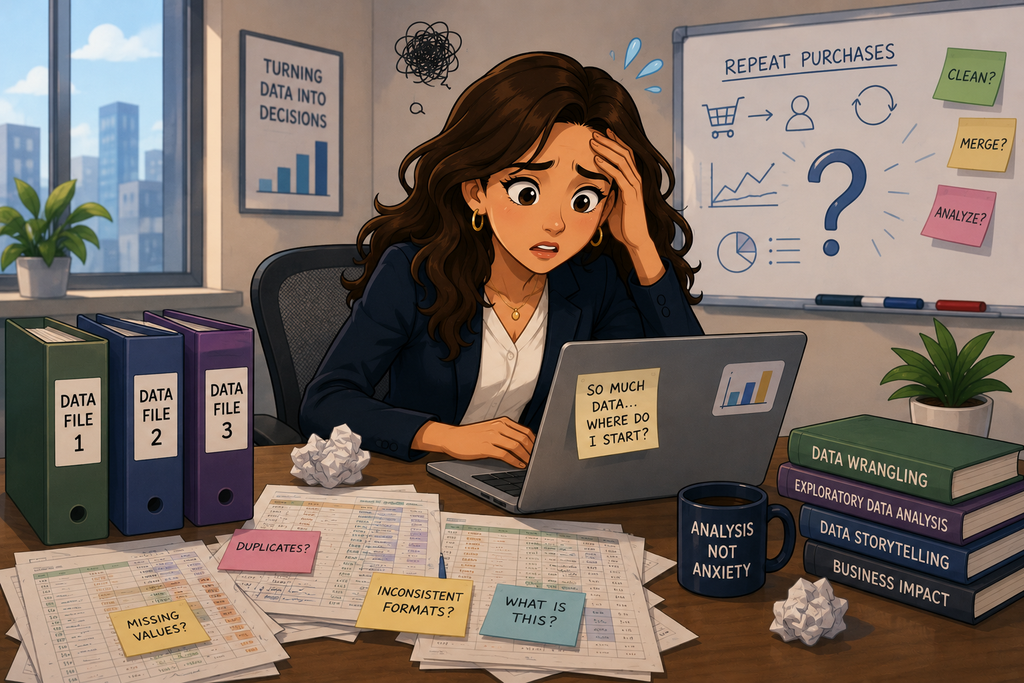

**What’s missing?** The hands-on ability to take raw, messy data and turn it into insight someone can act on.

**Important**

**That gap is exactly what this course closes.**

# Does this scenario sound familiar?

## It’s your turn to experience this…

You’ll get three datasets:

- 🧾 **Customer Transactions** (messy!)
- 🛒 **Product Information**
- 👥 **Customer Demographics**

Download the data from

https://tinyurl.com/retail-data

**Your mission:**

1. Get this data into a form where you can start answering: *“What drives repeat purchases?”*
2. Can you get some initial insights from the data?

## Group Activity: Dig Into the Data

Work in groups of 2–3. Use any tools you have (Excel, Python, intuition) and try to answer:

- 🛒 Which products have the highest repeat purchase rate?
- 👥 Are certain types of customers buying these products more frequently?
- 📅 Is there a time pattern — do repeat purchases cluster around certain days or weeks?
- 🧹 What data quality issues did you run into? Missing values? Inconsistent formats?
- 🔀 How did you connect information across the three files?

Please work on this for 15 minutes.

**Important**

Don’t worry about getting the “right” answer — focus on what’s hard about the process.

## Debrief: What Did You Learn?

Let’s talk through what you found:

- 🛒 Were you able to identify which products had the highest repeat purchase rate? What made it hard?
- 👥 Did any customer segments stand out? How did you figure that out?
- 📅 Did you find any time patterns — and how did you look for them?
- 🧹 What data quality issues slowed you down?
- 🔀 How did you connect the three files — and what would have helped?

**Tip**

If you couldn’t complete the task — or didn’t know where to start — **that’s exactly the point.** By the end of this course, this will feel straightforward.

## Key Takeaways:

- Real-world data is never clean or ready to analyze
- Good data work starts with **understanding the structure and quality** of your data
- This course will teach you to **clean, explore, model, and communicate** insights from messy data with Python

**Tip**

*We’ll revisit this exact challenge at the end of the semester — and it’ll feel completely different.*

# Course Overview

## Why This Matters for YOUR Career

Data is everywhere — but insight is rare.

**No matter your major, this course gives you a competitive edge:**

- 📊 **Business Analytics Students** → Speak the language of data science teams
- 📈 **Marketing Majors** → Understand customer behavior through data, not just theory
- 💵 **Finance Majors** → Model risk, detect fraud, forecast performance with code
- 👩‍💼 **Management Majors** → Lead data-driven decisions instead of following them
- 🎯 **All Majors** → Collaborate effectively with technical teams

**Important**

Today’s business leaders are expected to be **data-literate decision makers**

## What You’ll Learn in BANA 4080

```
flowchart LR
  subgraph DM[Data Mining]
    direction LR
    subgraph Data
    end
    subgraph Cleaning
    end
    subgraph Wrangling
    end
    subgraph EDA
    end
    subgraph Modeling
    end
    subgraph Interpretation
    end
  end
  A[Stakeholders] --> DM
  B[Organizational Requirements] --> DM
  DM --> Decisions --> Value
  Data --> Cleaning --> Wrangling --> EDA --> Modeling --> Interpretation
  Interpretation --> Data
```

By the end of this course, you’ll be able to:

- Write basic Python code to work with data
- Clean, wrangle, and analyze messy real-world datasets
- Visualize insights clearly and effectively
- Understand how various ML/AI models are used in organizations
- Build simple ML/AI models for prediction and pattern discovery
- Communicate data-driven findings to others

**Important**

This course is not about memorizing syntax — it’s about **thinking with data**

# AI Reality Check

## What About AI? Won’t It Do This for Me?

> *“Why do I need to learn coding when ChatGPT can just do it for me?”*

It’s a fair question. Let’s talk about it honestly.

🤖 **AI tools are incredible accelerators**, but they’re not magic:

- They don’t **understand your business context**
- They can’t **ask the right questions** about your data
- They sometimes just **make stuff up**
- They’re only as good as **your prompts and interpretation**

[figure not shown]

## AI Reality Check: It’s Like Autocorrect for Code!

**Warning**

**Ever had your phone turn “on my way!” into “omg my weasel!”?** 🦫

That’s exactly how AI coding tools work — they predict what comes next based on patterns they’ve seen.

Sometimes they nail it… sometimes you get digital weasels.

**AI tools are assistants, not autopilots:**

✅ **AI can help you:**

- Write boilerplate code
- Debug errors
- Learn new syntax
- Generate ideas

❌ **AI cannot:**

- Understand YOUR data
- Know YOUR business goals
- Ask the right questions
- Guarantee correct answers

## How We’ll Use AI in This Course

You’ll learn to use AI tools **as learning partners, not crutches:**

**✅ Smart AI Use:**

- Check your understanding
- Help debug when stuck
- Explain concepts differently
- Generate practice examples
- **Always understand what the code does**

**❌ Avoid This:**

- Copy-paste without understanding
- Skip the learning struggle
- Rely on AI for everything
- Submit AI code you can’t explain

**Important**

The future belongs to people who know how to **collaborate with AI**, not be replaced by it.

# Course Roadmap & Learning Mindset

## Learning to Code: A Reality Check

**Let’s be honest** — learning to code can be frustrating at first.

**You might feel:**

- 😤 Confused by error messages
- 🤯 Like everyone else “gets it” but you
- 😮‍💨 Stuck on simple problems
- 🙄 Like you’re just copying examples

**This is normal. It’s expected.**

[figure not shown]

**Learning to Code = Learning a New Language**

You’ll start by copying examples and Googling errors.

Over time, you’ll stop memorizing and start **thinking** in code.

**This course is designed for beginners** — we’ll get you there step by step!

# Course Roadmap

## Course Roadmap

Your journey through BANA 4080:

1. **Weeks 1–3**: Python basics & Working with data
2. **Weeks 3–4**: Data wrangling & Exploratory analysis
3. **Weeks 5-6**: Data visualization & Efficient programming
4. **Week 7**: Mid-term
5. **Weeks 8-12**: ML & AI
6. **Weeks 13-14**: Final project

**Important**

This course builds your skills step-by-step — like a training plan for thinking with data.

## How You’ll Learn

Each week follows a consistent rhythm:

- 🧠 **Tuesday (Lecture):** Learn concepts, explore examples, discuss ideas
- 💻 **Thursday (Lab):** Practice coding, get hands-on, work with real data

Assessments include:

- 📚 Weekly reading quizzes
- 📝 Biweekly homework assignments
- 💭 Discussion forums
- 📊 Midterm and final project
- ❌ No conventional tests!

**Important**

Expect to build something meaningful — not just learn theory.

## Resources

Everything You Need Is in One of Two Spots

#### 📍 Course Canvas Page

[figure not shown]

#### 📘 Course Textbook

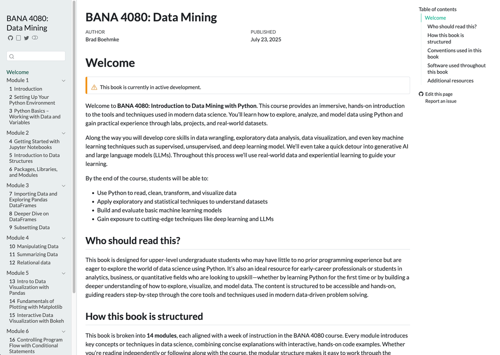

Book: https://bradleyboehmke.github.io/uc-bana-4080/

## Step 1

Who has read through the “Start Here!” module?

[figure not shown]

Let’s hit on a few important items

# Tools & Setup Preview

## Why Learn to Code? 🤔

- Coding = flexibility + power
- Handle real-world data: big, messy, inconsistent
- Automate repetitive tasks
- Think algorithmically and analytically

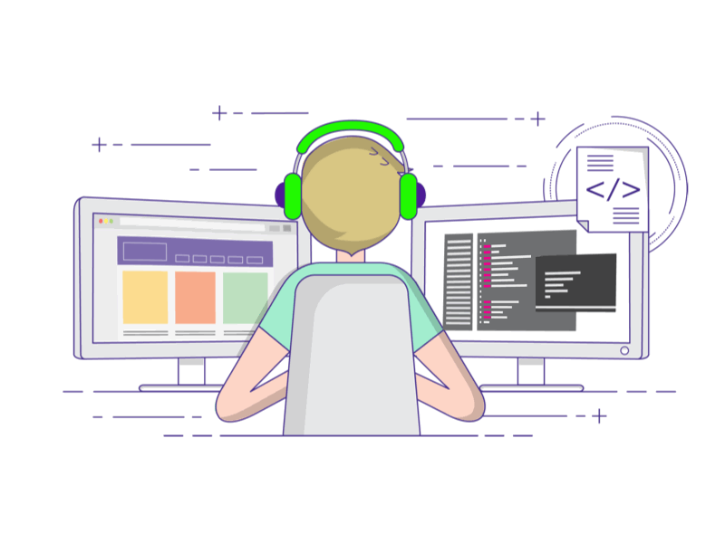

## Why Python? 🤔

- Widely used
- Easy-to-read syntax (great for beginners)
- Massive ecosystem: pandas, numpy, matplotlib, scikit-learn
- Community support: tutorials, libraries, AI tools
- **Most organizations are shifting toward Python** as the primary language for their **data science and engineering codebases**

[figure not shown]

**Important**

Python is the most valuable tool in your analytics toolbox.

## How You’ll Run Python: Google Colab

#### What is Colab?

- 💻 Free cloud-based Python environment from Google
- 🚫 No software installation needed to get started
- ✅ Works in your browser – just click and code

#### Why Colab First?

- Easy, consistent experience for everyone on Day 1
- Allows us to focus on learning — not debugging installs
- We’ll gradually move toward installing tools locally (e.g., Anaconda, Jupyter, VS Code)

[figure not shown]

**Important**

You’ll be up and coding on Day 1 — no setup headaches!

# Next Steps

## Your Learning Journey Starts Now

**📖 What Next?**

1. Read the “Start Here!” module
2. Start working through Module 1’s readings - **Chapters 1-3**
3. Get up and running in Colab

**🗓️ Thursday Lab:**

- Your **first Python code**
- Working in **Google Colab**
- **Collaborative problem-solving**

**💡 Remember:** We’re building skills step-by-step!

[figure not shown]

# Q&A

## Q&A 🙋‍♀️

- Open floor for any questions regarding the course structure, expectations, or content.
- Discussion on how this course aligns with your academic and career goals.
- Or anything else…golf?